author: Natalia Komornikova title: Tennis Matches Report

# Report on ATP and WTA Tennis Matches 2015-2023

## Stage I: Business Understanding

In this report we aim to understand tennis analytics with a focus on ATP and WTA tournaments from 2015 to 2023. The report will be focused on relationships between players performance and various variables such as surface, ranking etc. Our objective it to gain insight into player performance, surface preferences, and various match-related metrics. By doing this report we aim to provide valuable information that can benefit stakeholders or investors involved in tennis, such as players, coaches, tournament organizers, and potentially fans.

ATP and WTA refer to two main professional tennis organizations that govern men's and women's tennis.

- **ATP (Association of Tennis Professionals)** is the governing body for men's professional tennis. It organizes the majority of the men's tennis tournaments around the world. These tournaments are categorized into different levels, including Grand Slams (such as Australian Open, Wimbledon, Roland Garros), ATP Tour Masters 1000, ATP Tour 500, and ATP Tour 250. These tournaments further offer ranking points, and a player's ATP ranking is a crucial factor in determining the player's eligibility and seeding in tournaments.
- **WTA (Women's Tennis Association)** is on the other hand, the governing body for women's professional tennis. It is responsible for organizing and managing women's tennis tournaments globally. WTA tournaments also include Grand Slams etc. Similarly to ATP, players earn ranking points based on their performance in these tournaments.

Both ATP and WTA are attracting top tennis players from all around the world to showcase their skills on different surfaces like clay, grass, and hard court. The results of these tournaments influence players' standings, tournament seedings, and their overall careers in professional tennis.

Key aspects of this report include:

1. **Player-Surface Relationship:** Understand how players perform on different surfaces and identify any patterns or preferences.
2. **Match Outcome Prediction:** Building a model to predict future match results and other match-related features (duration, number of games, number of aces etc.).
3. **"Favourite" opponents:** Investigating the dynamics of player matchups, especially those with a highly unbalanced long-term score.
4. **Quality of Play Metrics:** Examining individual metrics like the share of double faults to identify unique player characteristics and playing styles.
5. **Ranking Impact on Match Results:** Analyzing the correlation between player rankings and match outcomes, with a potential focus on how this correlation varies across different surfaces.

The insights from this report could be valuable for making informed decisions in the tennis domain, such as strategic planning for players, optimizing training regimes etc.

## Stage II: Data Understanding

Data come from 18 different datasets - 9 from ATP tournaments and 9 from WTA tournaments. Each dataset contains matches that took place in the given year (2015-2023). These datasets have been aquired from [GitLab repository of the NDBI048 class](https://gitlab.mff.cuni.cz/mlyni8am/ndbi048/-/tree/master/data?ref_type=heads).

#### Size of the dataset

```
The number of rows in the merged dataset is:  46658
The number of columns in the merged dataset is:  49
```

```
The number of rows in the WTA dataset is:  22679
The number of rows in the ATP dataset is:  23979
```

```
The list of all columns in the merged dataset is:  ['tourney_id', 'tourney_name', 'surface', 'draw_size', 'tourney_level', 'tourney_date', 'match_num', 'winner_id', 'winner_seed', 'winner_entry', 'winner_name', 'winner_hand', 'winner_ht', 'winner_ioc', 'winner_age', 'loser_id', 'loser_seed', 'loser_…
```

#### Columns Description:

- `tourney_id` = unique identifier for tournaments
- `tourney_name` = name of the tournament (e. g. Wibledon, Roland Garros)
- `surface` = what surface was the match played on
- `draw_size` = Number of players in the draw - this number is often rounded up to the nearest power of 2
- `tourney_level` = For men: 'G' = Grand Slams, 'M' = Masters 1000s, 'A' = other tour-level events, 'C' = Challengers, 'S' = Satellites/ITFs, 'F' = Tour finals and other season-ending events, and 'D' = Davis cup. For women there are several additional tourney_level codes, including 'P' = Premier, 'PM' = Premier Mandatory, and 'I' = International. (The various levels of ITFs are given by the prize money (in thousands), such as '15' = ITF $15,000. Other codes, such as 'T1' for Tier I (and so on) are used for older WTA tournament designations. 'D' is used for Federation/Fed/Billie Jean King Cup, and also for Wightman Cup and Bonne Bell Cup). For both 'E' = exhibition, 'J' = juniors
- `tourney_date` = eight digits in the YYYYMMDD format, usually the Monday of the tournament week
- `match_num` = a match-specific identifier. Often starting from 1, sometimes counting down from 300, and sometimes arbitrary
- `winner_id` = the player_id used in this repo for the winner of the match
- `winner_seed` = the seeding of the player who won the match
- `winner_entry` = 'WC' = wild card, 'Q' = qualifier, 'LL' = lucky loser, 'PR' = protected ranking, 'ITF' = ITF entry, and there are a few others that are occasionally used
- `winner_name`
- `winner_hand` = R = right, L = left, U = unknown. For ambidextrous players, this is their serving hand
- `winner_ht` = height in centimeters
- `winner_ioc` = three-character country code
- `winner_age` - age in years as of the `tourney_date`
- `loser_id` = same as for winner
- `loser_seed` = same as for winner
- `loser_entry` = same as for winner
- `loser_name` = same as for winner
- `loser_hand` = same as for winner
- `loser_ht` = same as for winner
- `loser_ioc` = same as for winner
- `loser_age` = same as for winner
- `score`
- `best_of` = '3' or '5', indicating the number of sets for this match
- `round`
- `minutes` = match length
- `w_ace` = winner's number of aces
- `w_df` = winner's number of double faults
- `w_svpt` = winner's number of serve points
- `w_1stIn` = winner's number of first serves made
- `w_1stWon` = winner's number of first-serve points won
- `w_2ndWon` = winner's number of second-serve points won
- `w_SvGms` = winner's number of serve games
- `w_bpSaved` = winner's number of break points saved
- `w_bpFaced` = winner's number of break points faced
- `l_ace` = same as for winner
- `l_df` = same as for winner
- `l_svpt` = same as for winner
- `l_1stIn` = same as for winner
- `l_1stWon` = same as for winner
- `l_2ndWon` = same as for winner
- `l_SvGms` = same as for winner
- `l_bpSaved` = same as for winner
- `l_bpFaced` = same as for winner
- `winner_rank` = winner's ATP or WTA rank, as of the tourney_date or the most recent ranking date before the tourney_date
- `winner_rank_points` = number of ranking points, where available
- `loser_rank` = same as for winner
- `loser_rank_points` = same as for winner

#### Categories of the variables:

**Numeric:**

- draw_size
- match_num
- winner_id
- winner_ht (float)
- winner age
- loser_id, loser_ht, loser_age, best_of
- minutes
- w_ace
- w_df
- w_svpt
- w_1stIn
- w_1stWon
- w_2ndWon
- w_SvGms
- w_bpSaved
- w_bpFaced
- l_ace
- l_df
- l_svpt
- l_1stIn
- l_1stWon
- l_2ndWon
- l_SvGms
- l_bpSaved
- l_bpFaced
- winner_rank
- winner_rank_points
- loser_rank
- loser_rank_points

**Oridnal:**

- tourney_level
- round

**Nominal:**

- tourney_id
- tourney_name
- surface
- winner_hand
- winner_ioc
- loser_hand
- loser_ioc
- score

**Binary:**

- winner_entry
- loser_entry

#### Data quality

We need to check for duplicated rows in the dataset as we want to use row as a statistical unit for our goal. The goal is to predict future matches outcome and for that we need the rows of this dataset. Further in this report we will consider removing some columns.

```
0
```

> There is no duplicated row in our dataset

Here is a showcase of our merged dataset that we will be working with:

|  | tourney_id | tourney_name | surface | draw_size | tourney_level | tourney_date | match_num | winner_id | winner_seed | winner_entry | winner_name | winner_hand | winner_ht | winner_ioc | winner_age | loser_id | loser_seed | loser_entry | loser_name | loser_hand | loser_ht | loser_ioc | loser_age | score | best_of | round | minutes | w_ace | w_df | … |
| --- | --- | --- | --- | --- | --- | --- | --- | --- | --- | --- | --- | --- | --- | --- | --- | --- | --- | --- | --- | --- | --- | --- | --- | --- | --- | --- | --- | --- | --- | --- |
| 0 | 2015-339 | Brisbane | Hard | 28 | A | 20150104 | 1 | 105357 | NaN | WC | John Millman | R | 183.0 | AUS | 25.5 | 105733 | NaN | Q | Rhyne Williams | R | 185.0 | USA | 23.7 | 6-3 6-1 | 3 | R32 | 65.0 | 6.0 | 2.0 | … |
| 1 | 2015-339 | Brisbane | Hard | 28 | A | 20150104 | 2 | 103813 | NaN | NaN | Jarkko Nieminen | L | 185.0 | FIN | 33.4 | 106045 | NaN | Q | Denis Kudla | R | 180.0 | USA | 22.3 | 4-6 6-1 6-4 | 3 | R32 | 104.0 | 4.0 | 0.0 | … |
| 2 | 2015-339 | Brisbane | Hard | 28 | A | 20150104 | 3 | 105902 | NaN | WC | James Duckworth | R | 183.0 | AUS | 22.9 | 104468 | 6.0 | NaN | Gilles Simon | R | 183.0 | FRA | 30.0 | 6-2 6-2 | 3 | R32 | 68.0 | 4.0 | 0.0 | … |
| 3 | 2015-339 | Brisbane | Hard | 28 | A | 20150104 | 4 | 104871 | NaN | NaN | Jeremy Chardy | R | 188.0 | FRA | 27.8 | 104979 | NaN | NaN | Andrey Golubev | R | 185.0 | KAZ | 27.4 | 6-4 6-4 | 3 | R32 | 69.0 | 7.0 | 1.0 | … |
| 4 | 2015-339 | Brisbane | Hard | 28 | A | 20150104 | 5 | 105373 | NaN | NaN | Martin Klizan | L | 190.0 | SVK | 25.4 | 103781 | NaN | NaN | Jurgen Melzer | L | 183.0 | AUT | 33.6 | 6-7(5) 7-6(6) 6-1 | 3 | R32 | 144.0 | 9.0 | 4.0 | … |
| ... | ... | ... | ... | ... | ... | ... | ... | ... | ... | ... | ... | ... | ... | ... | ... | ... | ... | ... | ... | ... | ... | ... | ... | ... | ... | ... | ... | ... | ... | … |
| 46653 | 2023-W-FC-2023-QLS-M-SVK-ITA-01 | BJK Cup QLS R1: SVK vs ITA | Hard | 4 | D | 20230414 | 3 | 203533 | NaN | NaN | Anna Karolina Schmiedlova | R | 176.0 | SVK | 28.5 | 211148 | NaN | NaN | Jasmine Paolini | R | 160.0 | ITA | 27.2 | 6-1 4-6 6-4 | 3 | RR | NaN | NaN | NaN | … |
| 46654 | 2023-W-FC-2023-QLS-M-SVK-ITA-01 | BJK Cup QLS R1: SVK vs ITA | Hard | 4 | D | 20230414 | 4 | 214149 | NaN | NaN | Viktoria Kuzmova | R | NaN | SVK | 24.9 | 220714 | NaN | NaN | Elisabetta Cocciaretto | R | NaN | ITA | 22.2 | 6-3 7-6(2) | 3 | RR | NaN | NaN | NaN | … |
| 46655 | 2023-W-FC-2023-QLS-M-USA-AUT-01 | BJK Cup QLS R1: USA vs AUT | Hard | 4 | D | 20230414 | 1 | 221103 | NaN | NaN | Cori Gauff | R | 175.0 | USA | 19.0 | 211814 | NaN | NaN | Julia Grabher | R | 170.0 | AUT | 26.7 | 6-1 6-3 | 3 | RR | NaN | NaN | NaN | … |
| 46656 | 2023-W-FC-2023-QLS-M-USA-AUT-01 | BJK Cup QLS R1: USA vs AUT | Hard | 4 | D | 20230414 | 2 | 202468 | NaN | NaN | Jessica Pegula | R | 170.0 | USA | 29.1 | 221257 | NaN | NaN | Sinja Kraus | R | NaN | AUT | 20.9 | 6-0 7-5 | 3 | RR | NaN | NaN | NaN | … |
| 46657 | 2023-W-FC-2023-QLS-M-USA-AUT-01 | BJK Cup QLS R1: USA vs AUT | Hard | 4 | D | 20230414 | 3 | 202468 | NaN | NaN | Jessica Pegula | R | 170.0 | USA | 29.1 | 211814 | NaN | NaN | Julia Grabher | R | 170.0 | AUT | 26.7 | 6-1 6-3 | 3 | RR | NaN | NaN | NaN | … |

46658 rows × 49 columns

#### Checking the data quality

There are many missing values in this dataset as we can see below from a list of variables and the number of missing values for this variable in the dataset. The missing values are encoded either by `NaN` or is it's a numeric variable it is `0.0`.

```
tourney_id                0
tourney_name              0
surface                   0
draw_size                 0
tourney_level             0
tourney_date              0
match_num                 0
winner_id                 0
winner_seed           27277
winner_entry          40202
winner_name               0
winner_hand               6
winner_ht              2129
winner_ioc                0
winner_age                9
loser_id                  0
loser_seed            35386
loser_entry           36513
loser_name                0
loser_hand               34
loser_ht               3555
loser_ioc                 0
loser_age                16
score                     0
best_of                   0
round                     0
minutes                6053
w_ace                  2331
w_df                   2336
w_svpt                 2331
w_1stIn                2331
w_1stWon               2331
w_2ndWon               2331
w_SvGms                2648
w_bpSaved              2331
w_bpFaced              2331
l_ace                  2331
l_df                   2336
l_svpt                 2331
l_1stIn                2331
l_1stWon               2331
l_2ndWon               2331
l_SvGms                2648
l_bpSaved              2331
l_bpFaced              2331
winner_rank             412
winner_rank_points      412
loser_rank              863
loser_rank_points       863
dtype: int64
```

Let's have a look at the percentage of missing values for each variable.

|  | Missing Values | % of Missing vals |
| --- | --- | --- |
| winner_entry | 40202 | 86.2 |
| loser_entry | 36513 | 78.3 |
| loser_seed | 35386 | 75.8 |
| winner_seed | 27277 | 58.5 |
| minutes | 6053 | 13.0 |
| loser_ht | 3555 | 7.6 |
| w_SvGms | 2648 | 5.7 |
| l_SvGms | 2648 | 5.7 |
| w_df | 2336 | 5.0 |
| l_df | 2336 | 5.0 |
| l_2ndWon | 2331 | 5.0 |
| w_bpFaced | 2331 | 5.0 |
| l_bpSaved | 2331 | 5.0 |
| l_1stIn | 2331 | 5.0 |
| l_svpt | 2331 | 5.0 |
| l_ace | 2331 | 5.0 |
| l_bpFaced | 2331 | 5.0 |
| l_1stWon | 2331 | 5.0 |
| w_2ndWon | 2331 | 5.0 |
| w_bpSaved | 2331 | 5.0 |
| w_1stWon | 2331 | 5.0 |
| w_1stIn | 2331 | 5.0 |
| w_svpt | 2331 | 5.0 |
| w_ace | 2331 | 5.0 |
| winner_ht | 2129 | 4.6 |
| loser_rank | 863 | 1.8 |
| loser_rank_points | 863 | 1.8 |
| winner_rank | 412 | 0.9 |
| winner_rank_points | 412 | 0.9 |
| loser_hand | 34 | 0.1 |
| loser_age | 16 | 0.0 |
| winner_age | 9 | 0.0 |
| winner_hand | 6 | 0.0 |

**What to do with the missing values in different variables**

- There is a very high percentage of missing in `winer_entry` and `loser_entry` variable - we could either remove this column, or we could replace the missing values with Q (qualified) which is I think the most probable case and it is also the most abundant value of this variable in our dataset.
- `winner_seed` & `loser_seed` - I think that the seeding of the player is pretty correlated with the outcome of the match. There are 75.8% missing values in the `loser_seed` variable which I think we could replace with some high number. For the `winner_seed` variable it would be best to average the nonmissing values of this variable.
- `minutes` - I think minutes have an impact on the match outcome so we are going to keep this variable - we could compute the average length of a game and then add up the minutes based on the number of games that were played.

#### Building a heatmap

To see which variables are highly correlated we build a heatmap of our variables. We could reduce the number of variables on which the match outcome depends by seeing the correlation level of different variables.

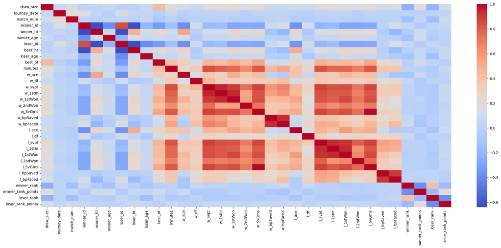

From this we can see that `w_svpt`, `w_1stIn` and `w_1stWon` as well as `l_svpt`, `l_1stIn` and `l_1stWon` are higly correlated.

> I suggest keeping only one of these for both winner and loser.

### Variable distributions

#### Share of won games for players by surface

#### Tournaments with the highest number of matches

To predict future matches outcome we need to consider what tournaments are our data from. In the graph below we can see that the tournaments with the highest number of matches played are the Grand Slams (US Open, Australian Open, Roland Garros and Wimbledon). These are the most popular tennis tournaments in the world and they are also the ones with the highest viewership.

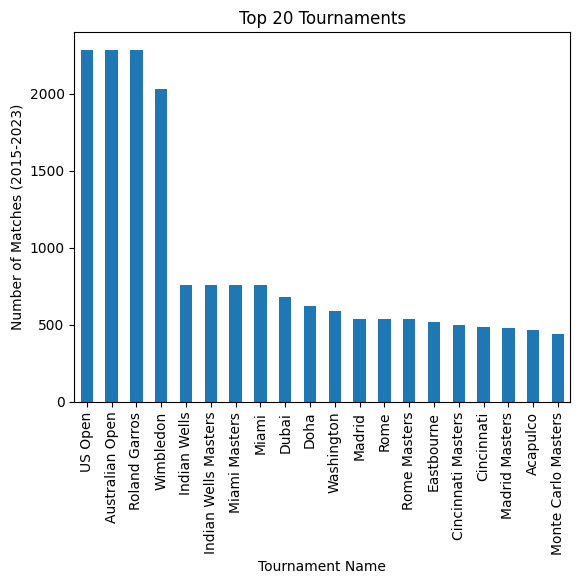

#### Entries of players

I want to look into this variable to decide wether to keep it or remove it from the dataframe. The most entries are `Q` as qualified which would make sense also for the missing values.

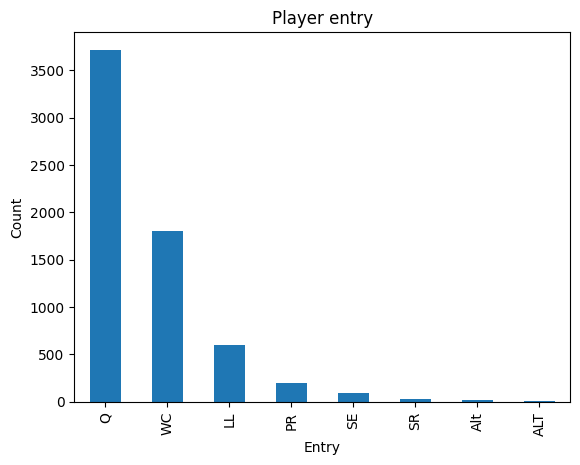

#### Surface

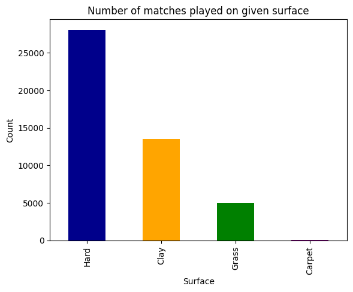

I would remove the Carpet rows from the dataframe since there is almost none match played on Carpet. (=suggestion for Data Preparation stage)

#### Share of won matches on different surface

Now lets look into the top players for each surface (excluding Carpet)

I created a table for both male and female players where I have their names and ids as the index and the surfaces as the columns. The values are then `number of matches the player won` - `number of matches the player lost`. Below we can see an example of this table for male players.

| player_id | surface player_name | Carpet | Clay | Grass | Hard |
| --- | --- | --- | --- | --- | --- |
| 100644 | Alexander Zverev | 0 | 81 | 15 | 117 |
| 102800 | Nenad Zimonjic | 0 | 0 | 0 | -2 |
| 103163 | Tommy Haas | 0 | -4 | -3 | -8 |
| 103188 | Michael Russell | 0 | 0 | 0 | -1 |
| 103285 | Radek Stepanek | 0 | 0 | -2 | -1 |
| ... | ... | ... | ... | ... | ... |
| 211776 | Martin Landaluce | 0 | 0 | 0 | -1 |
| 212021 | Martin Landaluce | 0 | -2 | 0 | 0 |
| 212037 | Amir Milushev | 0 | 0 | 0 | -1 |
| 212038 | Karam Hatamleh | 0 | 0 | 0 | -1 |
| 212041 | Jacob Bicknell | 0 | 0 | 0 | -1 |

1078 rows × 4 columns

In the following graphs we show:

1. Top 10 players with the highest number of matches won - matches lost on a given surface
2. Top 10 players with the best win rate for a given surface (this is a bit misleading since some players could have played only one match on the given surface and they won the match so their win rate is 1.0 - I will remove these players in Data Preparation stage)

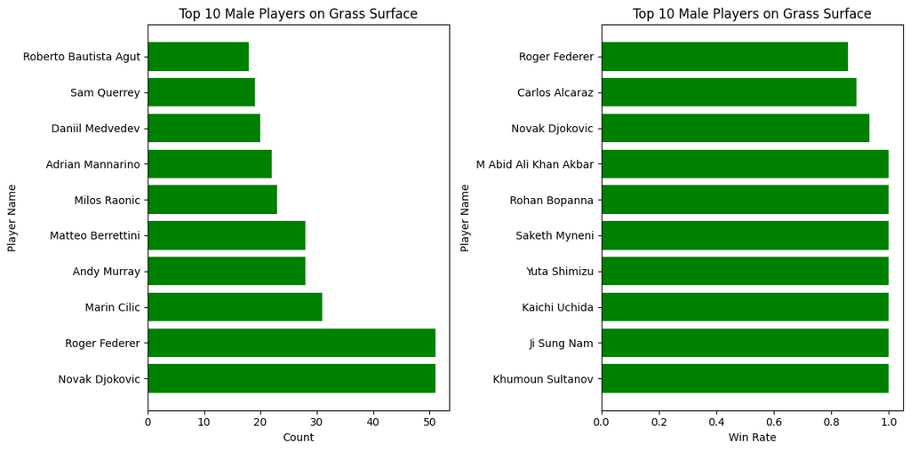

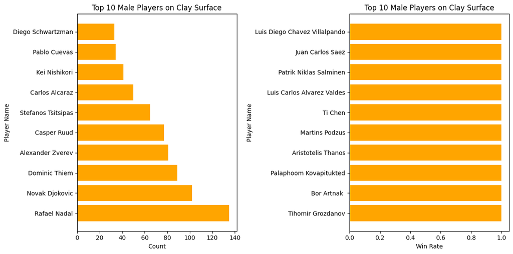

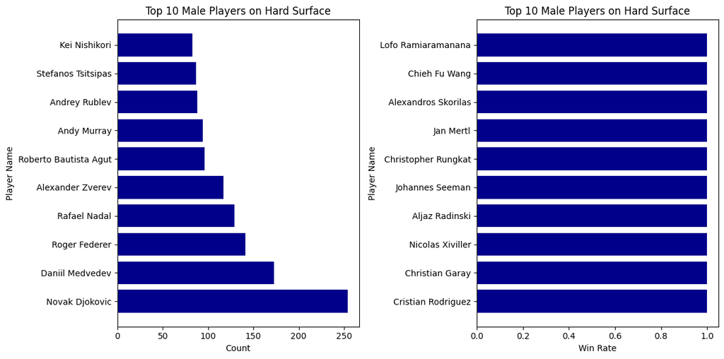

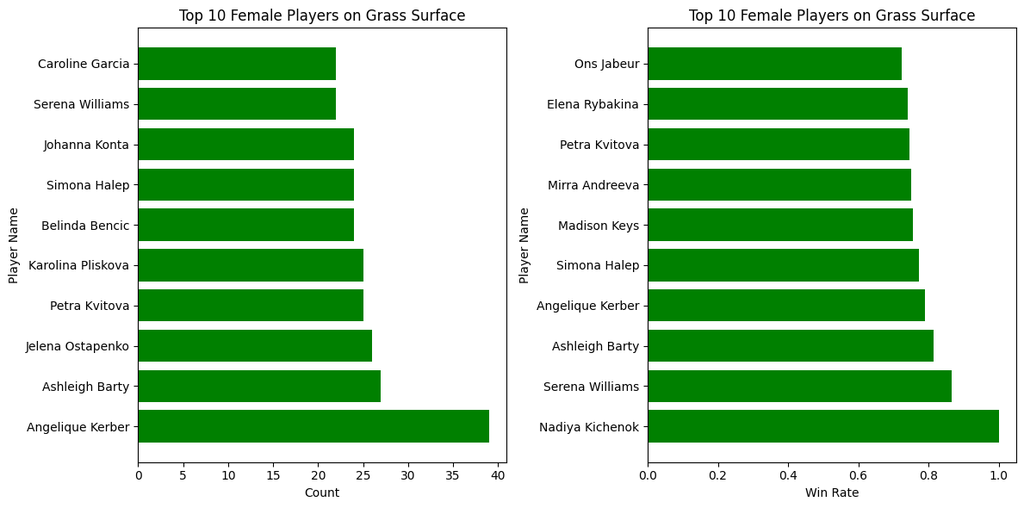

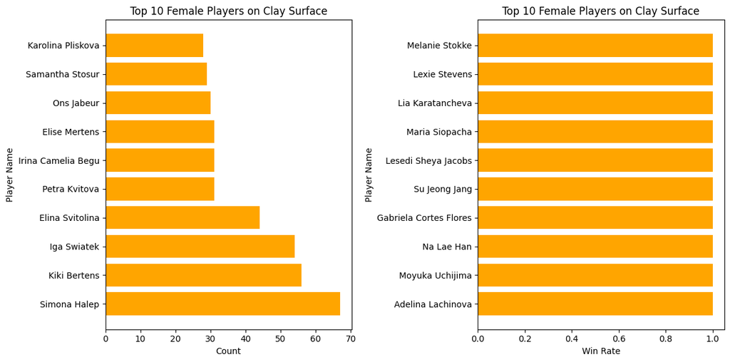

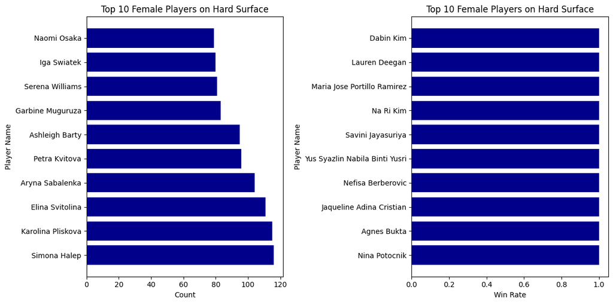

#### Match duration

I mentioned above that match outcome depends also on the length of the match. Therefore, I wanted to check the highest and the lowest lengths of the matches we have in our dataset.

Showing the longest matches:

```
The average length of a match is:  105.65632311291712  minutes, but we have 13% missing vals -> still need to prepare this for further modelling.
```

|  | tourney_id | tourney_name | tourney_date | match_num | minutes |
| --- | --- | --- | --- | --- | --- |
| 33677 | 2018-1101 | Lugano | 20180409 | 281 | 2475.0 |
| 32705 | 2018-0804 | Charleston | 20180402 | 298 | 1507.0 |
| 3075 | 2016-M001 | Sydney | 20160111 | 294 | 1146.0 |
| 32076 | 2017-M024 | Cincinnati | 20170814 | 293 | 1094.0 |
| 7141 | 2017-0308 | Munich | 20170501 | 297 | 987.0 |
| 10632 | 2018-540 | Wimbledon | 20180702 | 224 | 396.0 |
| 15468 | 2020-520 | Roland Garros | 20200928 | 1139 | 365.0 |
| 35021 | 2018-W-FC-2018-G2-AM-B-B-M-TTO-BAH-01 | Fed Cup G2 RR: TTO vs BAH | 20180719 | 2 | 361.0 |
| 32238 | 2017-W-FC-2017-G2-AM-B-M-GUA-DOM-01 | Fed Cup G2 RR: GUA vs DOM | 20170721 | 2 | 356.0 |
| 9729 | 2018-M-DC-2018-G1-AO-M-PAK-UZB-01 | Davis Cup G1 R2: PAK vs UZB | 20180406 | 1 | 356.0 |

Now showing the shortest non-zero long matches:

```
The average length of a match is:  105.65632311291712  minutes, but we have 13% missing vals -> still need to prepare this for further modelling.
```

|  | tourney_id | tourney_name | tourney_date | match_num | minutes |
| --- | --- | --- | --- | --- | --- |
| 44498 | 2023-2014 | Adelaide 2 | 20230109 | 290 | 1.0 |
| 41917 | 2022-2060 | Sydney | 20220110 | 292 | 1.0 |
| 43561 | 2022-1017 | Cincinnati | 20220815 | 283 | 1.0 |
| 43564 | 2022-1017 | Cincinnati | 20220815 | 280 | 1.0 |
| 42563 | 2022-2020 | Istanbul | 20220418 | 288 | 1.0 |
| 41879 | 2022-2030 | Adelaide 2 | 20220110 | 299 | 1.0 |
| 44012 | 2022-2025 | Ostrava | 20221003 | 289 | 1.0 |
| 43074 | 2022-710 | Eastbourne | 20220620 | 297 | 1.0 |
| 43613 | 2022-2040 | Cleveland | 20220822 | 286 | 1.0 |
| 43041 | 2022-2017 | Bad Homburg | 20220620 | 299 | 1.0 |

We can see that this is not a valid value for a match duration... It could have happen that a player scratched the match after one minute or something but we need to think of a way how to treat values like this. There are also many matches with duration of 0 minutes. This could also be the case where a player scratched the match. However, I think that predicting a future match outcome shouldn't take cases like this into account. So I believe it would be the best to remove matches that took less than a certain value.

- the certain value will be observed by averaging the typically long matches. This means removing ~ matches shorter than 35mins and longer than 6hours (360mins).

#### Number of matches distributed to months through each year

We will explore the distribution of number of matches in different months each year.

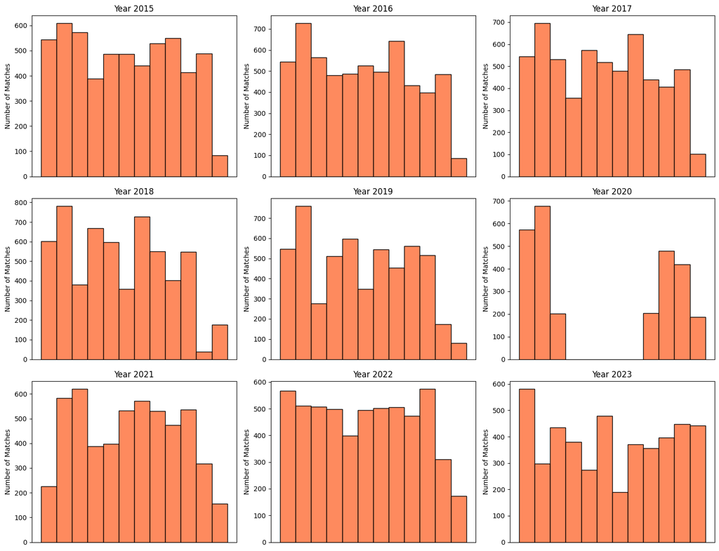

From the graph we can see higher peaks during the months where big Grand Slam tournaments take place. The distribution is very similar in years from 2015 till 2019. The covid pandemic started in 2020 and in that year we can see a gap from march till september where not a single match took place since the pandemic started and our lives stopped for a moment. The distribution of matches during the year changed a bit since covid which is an interesting observation.

I also wanted to see different patterns of distribution between WTA and ATP tournaments (WTA in red, ATP in blue).

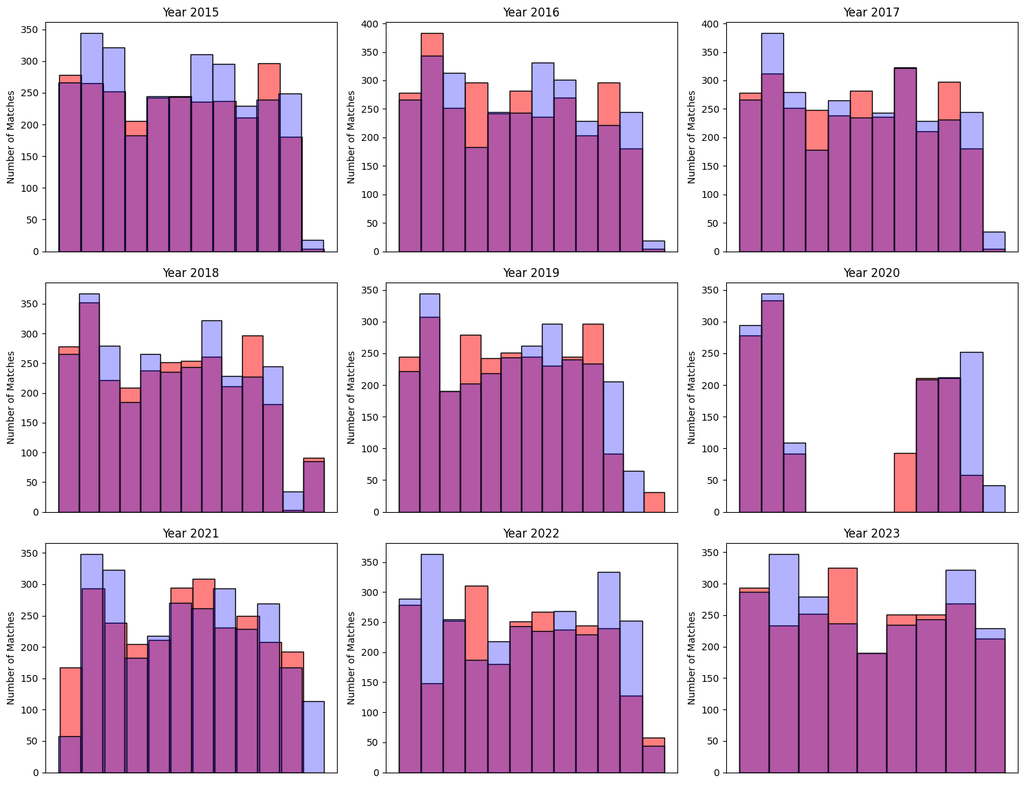

#### Correlation of ranking before the match and the match outcome

I want to check wether there is correlation between the rank of players and the outcome of the match. For this task I will create a new binary variable `higher_ranked_winner` in my dataset. This will be True if the difference between `loser_rank` - `winner_rank` is greater than 0 and False otherwise. The ranking in tennis is ordered from highest ranked player = rank 1 and then other players have a greater number. Thats why we want the value to be positive.

```
<__array_function__ internals>:200: RuntimeWarning: Converting input from bool to <class 'numpy.uint8'> for compatibility.
```

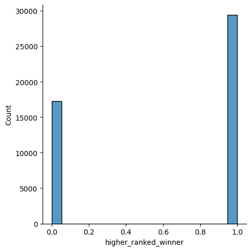

```
True     29385
False    17273
Name: higher_ranked_winner, dtype: int64
```

From the graph and from the `value_counts()` of this variable I assume there is correlation. However this assumption is not enough so I will use statistical t test to check it.

- **The null hypothesis is**: There is no correlation between the rank of the player before the match and the match outcome. (there is no significant difference between the number of matches where the winner had a higher rank before the match and the matches where the loser had a higher rank before the match.)
- **The alternate hypothesis**: There is correlation between the rank of the player before the match and the match outcome. (there is a significant difference between the number of matches where the winner had a higher rank before the match and the matches where the loser had a higher rank before the match.)

I'm going to use `ttest_ind` from `scipy.stats` to perform an independent two-sample t-test with unequal variances

```
Number of missing values in 'rank_difference': 0
Number of infinite values in 'rank_difference': 0
```

I added mean of the rank of players to the rows where there was a missing value since it is a significant variable for the match outcome.

```
T-statistic: 132.17056679749453
P-value: 0.0
```

**T test results**

T-statistic: The magnitude of the t-statistic indicates how many standard deviations the means of the two groups are apart. A larger absolute t-statistic suggests a more significant difference.

P-value: The very low p-value (approaching zero) indicates that the observed difference in `rank_difference` is highly unlikely to occur by random chance, supporting the rejection of the null hypothesis.

In conclusion, based on the statistical test, there is strong evidence to suggest that the rank difference between the winner and loser is significantly different between matches where the winner has a higher rank and matches where the loser has a higher rank.